# 共同住宅とその維持管理

岩田真一郎（神奈川大学経済学部）

2025-03-23作成，2025-05-04改訂

［PDF形式：322KB］

修繕積立金が不足すれば，本来は積立金を増額することで対応できます．しかし，マンション住民（**区分所有者**）間で合意を得るのは容易ではなく，実際には増額が難しいケースが多く見られます（岸田，2024）．本稿では，共同住宅における維持管理が望ましい水準に達しにくい背景を，ミクロ経済学の視点から説明します．

# 1 専有部分と共用部分

共同住宅では，各部屋に所有権が設定されます．これらの部屋を**専有部分**とよび，専有部分の所有者を区分所有者とよびます. 「区分」と記されるのは，建物全体の所有者ではないためです．共同住宅には専有部分のほか，建物の躯体やエントランス，廊下，階段，エレベーターなど，区分所有者全体で共同所有する[**共用部分**](https://ja.wikipedia.org/wiki/%E5%85%B1%E7%94%A8%E9%83%A8%E5%88%86)があります．専有部分の維持管理は各区分所有者が行いますが，共用部分については通常，[管理組合](https://ja.wikipedia.org/wiki/%E7%AE%A1%E7%90%86%E7%B5%84%E5%90%88)を設立し，区分所有者から徴収する費用（**維持管理費**）をもとに維持管理を行います．維持管理費には，日常的な管理のための**管理費**と，計画的に実施される大規模修繕のための修繕積立金が含まれます．国土交通省（2024）は，この後者の資金が不足しているという内容です．

# 2 一戸建の維持管理

共同住宅の共用部分の維持管理の難しさを理解するために，一戸建の維持管理ついて考えてみましょう．

図1は，一戸建の所有者sの維持管理（投資）に対する需要曲線（D<sub>s</sub>）を示しています．通常の右下がりの需要曲線のように，ここでは維持管理の単位費用（価格）が下落するにつれて，維持管理の需要が増加すると仮定します．

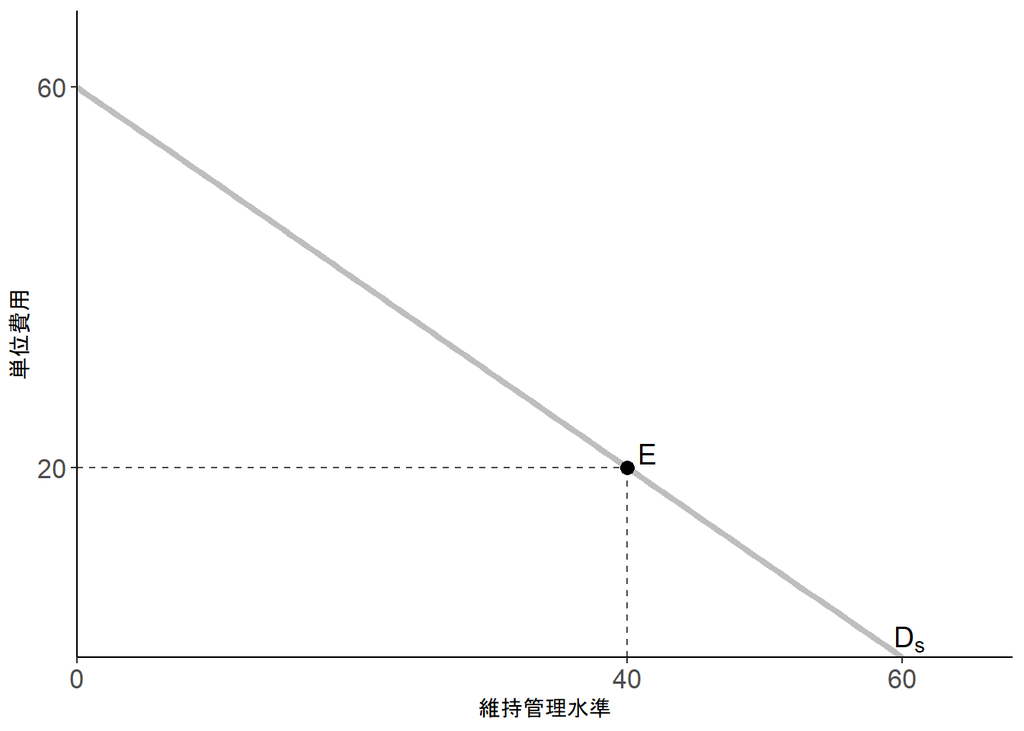

図1：一戸建の維持管理水準

維持管理の単位費用が20だったとしましょう．このとき，一戸建の所有者sはE点で消費者余剰が最大になりますから，最適な維持管理水準は40になります[^1]．図1の数値例から，所有者sの便益は1600（0から維持管理水準40までの需要曲線の下の面積＝上底20，下底60，高さ40の台形面積），維持管理費（支出）は800（単位費用20×維持管理水準40）ですので，消費者余剰（便益ー支出）は800になります．

# 3 共同住宅の維持管理

一戸建では，消費者余剰を最大にする最適維持管理水準が達成されます．それに対して，共同住宅では，維持管理費が十分集まらず，維持管理の水準が最適になりません（これを，本稿では**共同住宅の失敗**とよぶことにします）．これは，共用部分の維持管理が**公共財**だからです．

## 3.1 公共財としての維持管理

共同住宅の失敗を説明する前に，まず公共財について触れましょう．公共財は，ミクロ経済学やその応用分野である公共経済学に登場し，通常の財（**私的財**）とは異なり，**非競合性**と**非排除性**を備えた財です．

非競合性とは，ある人が財を消費しても，他の人の消費量が減らない性質を指します．つまり，同時に多くの人が消費できることを意味します．例えば，あるリンゴを一人が食べてしまうと，他の人はそのリンゴを食べることができません．したがって、リンゴは非競合性を持ち合わせません．一方，共同住宅のエントランスなどの共用部分がきれいに保たれていると，区分所有者全員がその恩恵を同時に受けることができ，非競合性を持ち合わせているといえます．

非排除性とは，対価を支払わない人をその消費から排除できない性質です．リンゴの場合，リンゴを購入しなければ食べることができませんが，共同住宅の維持管理は，その費用を支払っていない住民にも影響を及ぼします．共同住宅では，維持管理費を徴収していますので，支払わない住民には退去を求めることができます．しかし，問題は資金不足により大規模修繕ができなくなった場合です．この場合，積立金の増額が求められることがありますが，反対する住民を退去させることはできません．そのため，仮に大規模修繕が実施されると，対価を支払わない住民も共用部分の修繕の恩恵を受けることになります．このように，建物の共用部分の維持管理には非排除性が備わっています．

## 3.2 共同住宅の維持管理需要

次に，共同住宅の維持管理の需要曲線を考えます．図2は，図1の一戸建が分割され，建物を区分所有者aと区分所有者bで共同所有している場合を考えています．ここで，横軸は専有部分ではなく，共用部分の維持管理水準を表しています．また，後ほど比較しやすいように，図2のD<sub>c</sub>とE点の位置は図1のD<sub>s</sub>とE点の位置と同じになるように描いています．

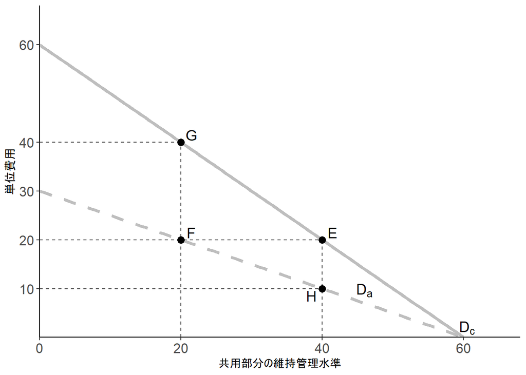

図2：共同住宅の維持管理需要曲線

図2のD<sub>a</sub>は，区分所有者aの維持管理に対する需要曲線を示しています．なお，D<sub>a</sub>の位置は，D<sub>c</sub>の位置からちょうど1/2だけ低くなるように描いています．例えば，維持管理が0のとき，D<sub>c</sub>の高さは60であるのに対して，D<sub>a</sub>の高さはその1/2である30です．同様に，維持管理水準が20のとき，D<sub>c</sub>の高さは40であるのに対して，D<sub>a</sub>の高さは20，維持管理水準が40のとき，D<sub>c</sub>の高さは20であるのに対して，D<sub>a</sub>の高さは10になっています．

ここで，区分所有者aが共用部分に対して20の水準の維持管理を需要したとしましょう．このとき，区分所有者aの便益は500（0から維持管理水準20までの需要曲線D<sub>a</sub>の下の面積＝上底20，下底30，高さ20の台形面積）になります．仮にこの建物が一戸建の場合，便益はこの500だけになります．しかし，共同住宅の場合，共用部分の維持管理は，非競合性から区分所有者bの便益にも影響を及ぼします．そこで，簡単化のため，区分所有者bは区分所有者aと同質と仮定し，維持管理に対する需要曲線D<sub>b</sub>はD<sub>a</sub>と同一になるとしましょう．このとき，区分所有者bの便益も500になるはずです．図2において，この面積は，上底が線分GF（20），下底が縦軸の切片60と30の差（30），高さ20（維持管理水準）の台形面積に等しくなります．したがって，0から維持管理水準20までの曲線D<sub>c</sub>の下の面積が全区分所有者の便益になります．維持管理水準40のときも同様です．このとき，区分所有者aの便益は800（0から維持管理水準40までの需要曲線D<sub>a</sub>の下の面積）に，区分所有者bの便益も800（上底が線分EH，下底が縦軸の切片60と30の差，高さ40の台形面積）になり，全区分所有者の便益は1600（0から維持管理水準40までの曲線D<sub>c</sub>の下の面積＝上底20，下底60，高さ40の台形面積）になります．

このことは，曲線D<sub>c</sub>が全区分所有者の共用部分の維持管理に対する需要曲線になることを意味します．実際に，公共財の需要曲線は，個別需要曲線を**垂直方向**に足し合わせることで求まります．今回の場合は，同質的な個人が2人のため，区分所有者aの需要曲線D<sub>a</sub>を垂直方向に2倍すればよいことになります．したがって，全区分所有者の需要曲線は，D<sub>a</sub>に比べてちょうど2倍の高さにあるD<sub>c</sub>と等しくなります．

## 3.3 最適維持管理水準

各区分所有者は維持管理費800のうち，半分の400を負担するとしましょう．図3では，黒枠の四角形のうち灰色で塗りつぶされた四角形が400と等しくなります．これは，区分所有者aが維持管理単位あたり10を負担し，合計400（10×40）を負担することで実現可能です．需要曲線D<sub>a</sub>の下で，区分所有者aの消費者余剰が最大になるのはH点になります．区分所有者aの便益は0から維持管理水準40までの需要曲線D<sub>a</sub>の下の面積800になりますので，消費者余剰は400になります．

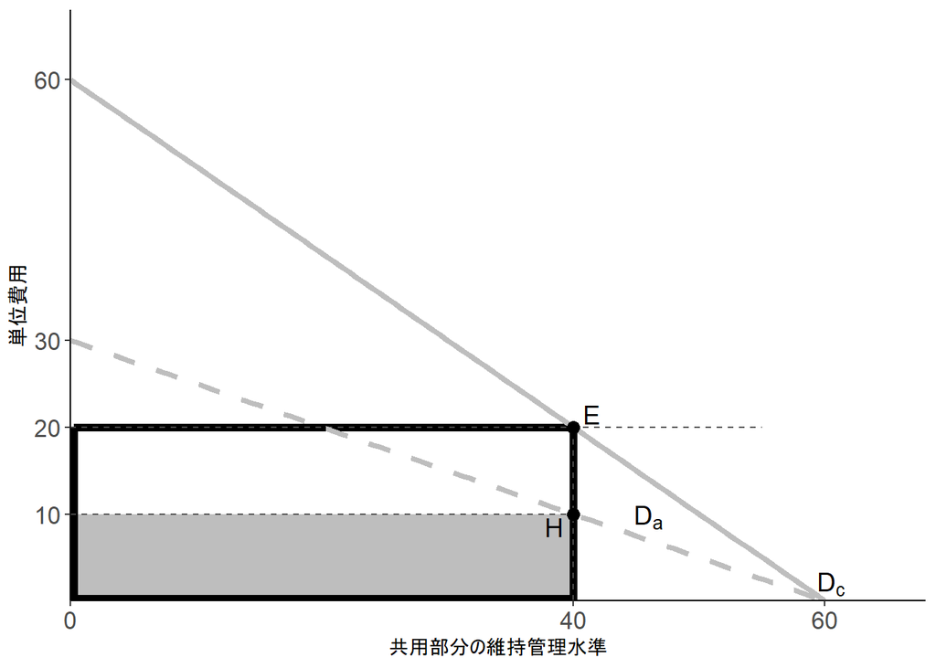

図3：共同住宅の最適維持管理水準

## 3.4 共同住宅の失敗

最後に，共用部分の維持管理水準が40にならず，共同住宅の失敗が生じることを見ていきましょう．このような結果が生じるのは，区分所有者にとって40の水準に反対することが合理的だからです．そこで，区分所有者bが400の維持管理費を負担することを前提として，区分所有者aが維持管理費の負担を200しか負担しない場合を考えます．このとき，2人合計の維持管理費は図4の黒枠の四角形600になるため，維持管理水準は30（＝600÷20）にとどまります．しかし，維持管理水準が減少しても，区分所有者aの負担は図4の灰色で塗りつぶされた部分で済むため，消費者余剰は475に増加します．したがって，区分所有者aには維持管理費の負担を400から200に引き下げる誘因が生じます．このように，公共財の非排除性を利用し，少ない負担でその恩恵を受けようとする人は，ミクロ経済学で**フリーライダー**とよばれます．一方，区分所有者bは（黒枠の四角形から灰色で塗りつぶした四角形を差し引いた）400の維持管理費を負担したままなので，消費者余剰は275に減少します．

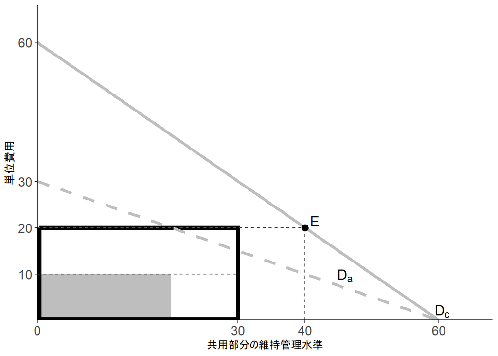

図4：共同住宅の失敗

以上から，全区分所有者の消費者余剰は各区分所有者の消費者余剰を合計した750になり，最適な維持管理水準のもとで達成される消費者余剰800よりも減少します．共用部分の維持管理は，区分所有者aがフリーライダーになることによって，過小になります．

この問題は，共同住宅特有の失敗です．一戸建の場合，維持管理の便益は，維持管理を負担した所有者自身に帰着しますが，共同住宅の場合，維持管理の便益が，区分所有者自身だけではなく，維持管理を負担しない他の区分所有者にも及んでしまいます．この結果，区分所有者の中に，費用を免れようとする人が現れ，最適な維持管理水準を達成するために必要な資金を集められなくなってしまいます．

## 3.5 ナッシュ均衡

それでは，区分所有者bはフリーライダーにならないのでしょうか？区分所有者bは区分所有者aと同質であるため，同じ行動を取るはずです．すなわち，区分所有者aが400を負担するのであれば，自身は負担を引き下げることで消費者余剰を増やせるため，負担を200に引き下げようとします．

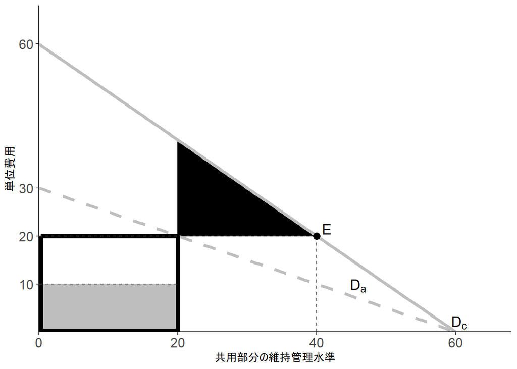

図5：維持管理のナッシュ均衡

この結果，2人ともフリーライダーになるため，維持管理費は合計で400にまで減少します．これは，図5の黒枠の四角形の面積になります．したがって，維持管理水準は20（400÷20）にさらに低下します．

消費者余剰はどうなるでしょうか？全区分所有者の便益は0から維持管理水準20までの需要曲線D<sub>c</sub>の下の面積1000，維持管理費は400ですから，消費者余剰は600になります．すなわち，図5の黒い三角形の面積だけ消費者余剰が減少します．

各人の消費者余剰はどうなるでしょうか？区分所有者aの便益は0から維持管理水準20までの需要曲線D<sub>a</sub>の下の面積500，維持管理費はグレーの四角形200ですから，消費者余剰は300になります．区分所有者bの消費者余剰も300になります．

それでは，区分所有者bが200の維持管理費を負担することを前提として，区分所有者aが維持管理費の負担を変更する誘因はあるでしょうか？仮に，負担を400に上げた場合，消費者余剰は275に減少し，逆に負担を100に下げた場合も消費者余剰は293.75に減少します[^2]．したがって，区分所有者aが維持管理費の負担を変更する誘因は生じません．同様に，区分所有者bにもそのような誘因は生じません．

以上から，維持管理水準は最適維持管理水準40よりも20低い20に落ち着きます．このとき，維持管理費は400であり，各区分所有者の維持管理費の負担は200になります．そして，この負担の組み合わせは**ナッシュ均衡**となります[^3]．そのことを，利得表を使って説明しましょう．

これまで検討した各区分所有者の消費者余剰は以下の四つの戦略の組み合わせ

- 区分所有者aが「負担200」，区分所有者bも「負担200」
- 区分所有者aが「負担200」，区分所有者bは「負担400」
- 区分所有者aが「負担400」，区分所有者bは「負担200」
- 区分所有者aが「負担400」，区分所有者bも「負担400」

に応じて決まりました．その結果，表1のような利得表を得られます．

表1：利得表

|  |  | b |  |
| --- | --- | --- | --- |
|  |  | 負担200 | 負担400 |
| a | 負担200 | （300, 300） | （475, 275） |
|  | 負担400 | （275, 475） | （400, 400） |

括弧内の数値は左が区分所有者aの消費者余剰，右がbのそれを示す．

仮に区分所有者bが「負担200」を選んだとしましょう．このとき，区分所有者Aは「負担200」を選択すると，消費者余剰は300 になります．一方，「負担400」を選択すると，消費者余剰は275に減少します．したがって，区分所有者bが「負担200」を選んだ場合，区分所有者aは「負担200」を選択することになります．

次に，仮に区分所有者bが「負担400」を選んだ場合の区分所有者aが選ぶ戦略を考えてみましょう．区分所有者aは「負担200」を選択すると，消費者余剰は475に増加します．一方，「負担400」を選択すると，消費者余剰は400にとどまります．したがって，区分所有者bが「負担400」を選んだ場合，区分所有者Aは消費者余剰が大きくなる「負担200」を選択することになります．

このように，区分所有者aは区分所有者bが選ぶ戦略に関わらず「負担200」を選びます．したがって，「負担200」は支配戦略です．

区分所有者bは，区分所有者aと同質ですから，区分所有者bにとっても「負担200」は支配戦略になります．

以上から，最終的に選ばれる戦略の組み合わせは表2の背景が灰色，数字が太字の部分になります．すなわち，

- 区分所有者aが「負担200」，区分所有者bも「負担200」

という戦略の組み合わせです．この戦略の組み合わせがこのゲームのナッシュ均衡になります．

表2：ナッシュ均衡

|  |  | b |  |
| --- | --- | --- | --- |
|  |  | 負担200 | 負担400 |
| a | 負担200 | （300, 300） | （475, 275） |
|  | 負担400 | （275, 475） | （400, 400） |

括弧内の数値は左が区分所有者aの消費者余剰，右がbのそれを示す．

残念なことは，両者が「負担400」を選んだ方が各自の消費者余剰は高くなるにもかかわらず，どちらも「負担200」を選んでしまい，最終的に囚人のジレンマに陥ることです．共同住宅は，共用部分の維持管理に関してこのような課題を抱えています．

# 参考文献

- 岸田幸子（2024）[「マンション修繕積立金の誤算 ｢段階増額｣合意にハードル」](https://www.nikkei.com/article/DGXZQOUB1737X0X11C24A1000000/)『日本経済新聞』2024年11月25日．↩︎
- 国土交通省（2024）[「令和５年度マンション総合調査結果からみたマンションの居住と管理の現状」](https://www.mlit.go.jp/jutakukentiku/house/content/001750158.pdf)（アクセス日：2025-03-22）．↩︎
- 総務省（2024）[「令和５年住宅・土地統計調査 住宅及び世帯に関する基本集計（確報集計）結果」](https://www.stat.go.jp/data/jyutaku/2023/pdf/kihon_gaiyou.pdf)（アクセス日：2025-03-21）．↩︎

# R環境

**セッション情報**

- R version 4.4.3 (2025-02-28 ucrt)
  - RStudio 2024.12.1+563
  - rmarkdown_2.29

**使用したパッケージ**

- `gt`
- `tidyverse`

# リンク

[都市経済学講義ノート](https://shinichiro-iwata.github.io/lecture-notes-urban-econ/)

[Rによる地理空間データの可視化](https://shinichiro-iwata.github.io/geospatial-data-visualization/)

[Shinichiro Iwata](https://shinichiro-iwata.github.io/)

**アイコン**

Font Awesome 6.3.0

**生成AIの使用について**

ChatGPTのサービスを利用した後，内容を確認し，必要に応じて編集を行いました．

[^1]: 消費者余剰の詳細は，[住宅価格と住宅政策](https://shinichiro-iwata.github.io/lecture-notes-urban-econ/housing-price-and-policy.html)の第1節「個別需要曲線，消費者余剰，市場需要曲線」を参照してください．
[^2]: 区分所有者aが100，区分所有者bの負担が200のとき，維持管理費は2人合計で300ですから，維持管理水準は15（300÷20）に減少します．
[^3]: ナッシュ均衡についての詳細は，[地方自治体間の子ども医療費助成競争](https://shinichiro-iwata.github.io/lecture-notes-urban-econ/medical-expense-subsidies.html)を参照してください